# Exercise 1

## Map

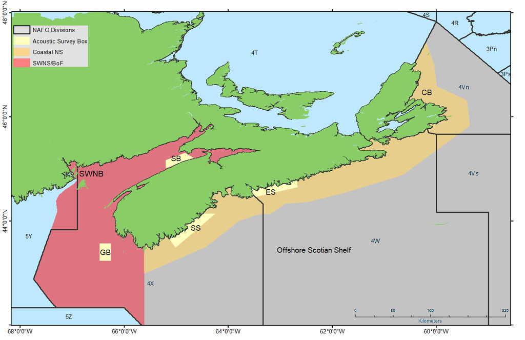

**Figure 1. Map of herring fishing areas in NAFO area 4VWX**  
Summary of management components for the 4VWX herring stock:  
• SWNS/BoF management component: red shading, SB = Scots Bay spawning area; GB = German Bank spawning area  
• Offshore Scotian Shelf management component – grey shading, area in 4VWX east of SWNS/BoF and greater than ~25 miles from shore.  
• Coastal NS management component: gold shading, area in 4VWX east of SWNS/BoF and within ~25 miles from shore. SS = South Shore; ES = Eastern Shore; CB = Cape Breton.  
• SWNB Weir management component = Southwest New Brunswick (herring landed by weir in coastal SWNB). Note: herring landed in SWNB by other gear types are included in the SWNS/BoF management component

## Data

### All 4VWX

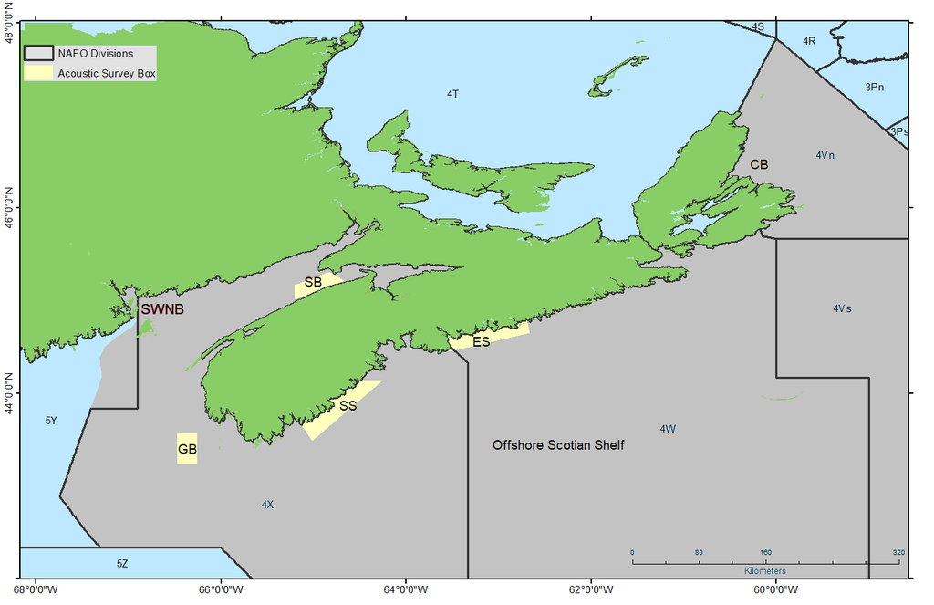

**Figure 2.1.1 Map of herring fishing areas in NAFO area 4VWX**

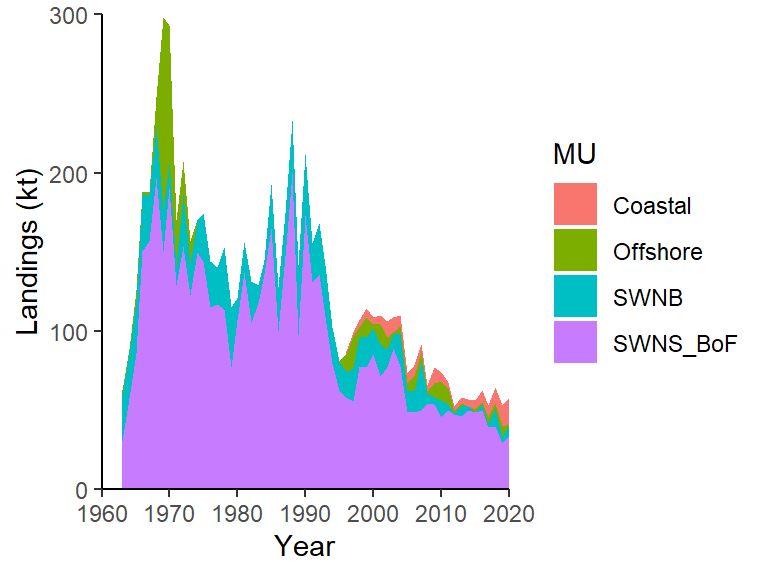

**Fig 2.1.1 Landings by Management Component (Total 4VWX)**

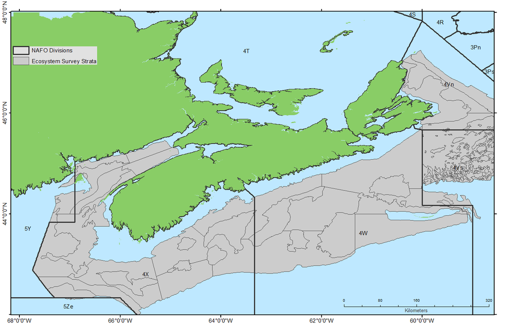

**Fig 2.1.3 Groundfish RV survey strata with sufficient data in 4VWX to generate a biomass index**

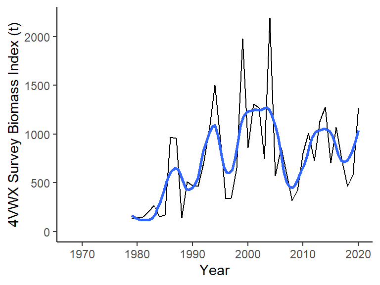

**Fig 2.1.4 Biomass Index from groundfish RV survey (Strata with sufficient data in 4VWX)**  
*Blue line = loess smoother with span = 0.25*

### SWNS/BoF

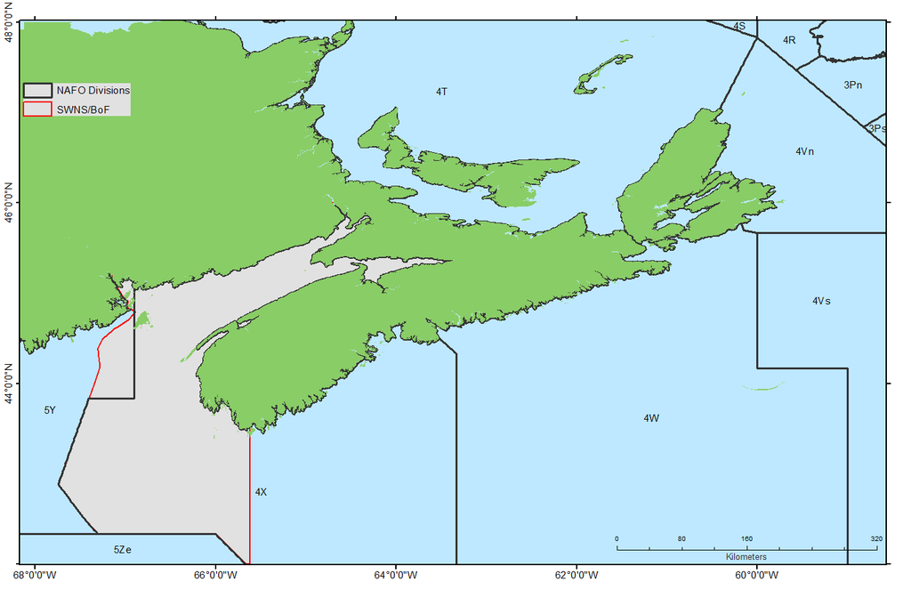

**Figure 2.2.1 Map of spatial area of SWNS/BoF**

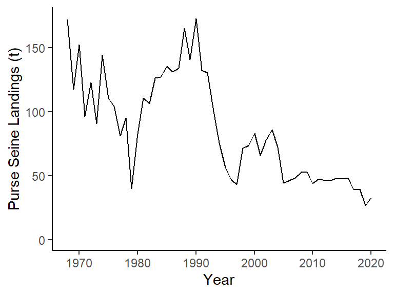

**Figure 2.2.2 Landings for Purse Seine Fleet in SWNS/BoF**

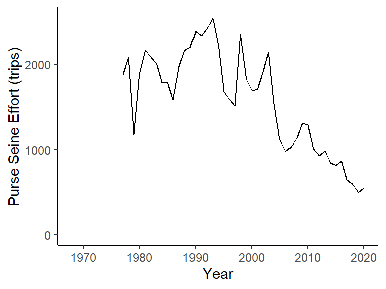

**Figure 2.2.3 Total Effort for Purse Seine Fleet in SWNS/BoF**

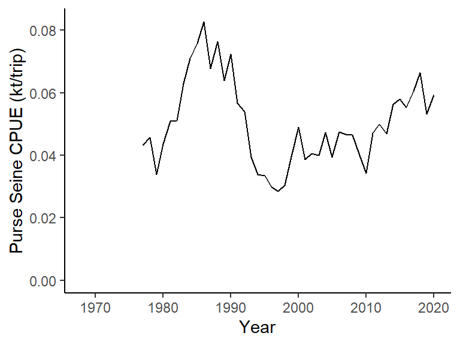

**Figure 2.2.4 CPUE for Purse Seine Fleet in SWNS/BoF**

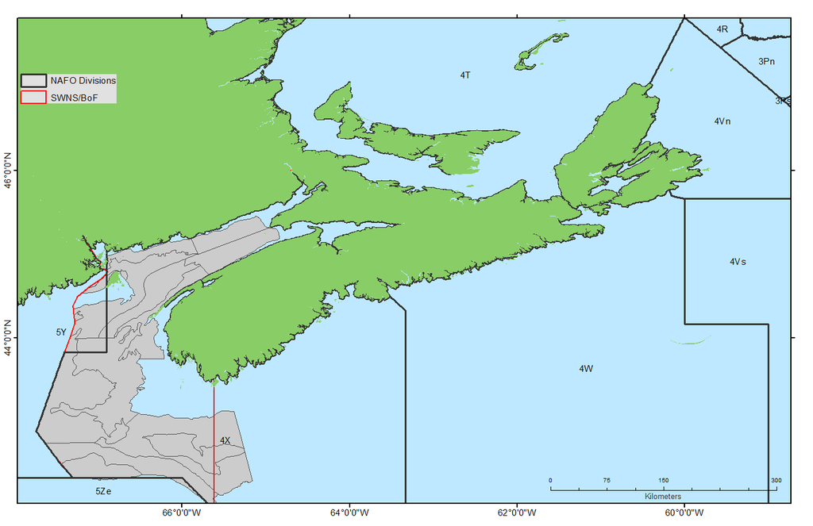

**Figure 2.2.5 Groundfish RV survey strata with sufficient data in SWNS/BoF to generate a biomass index**

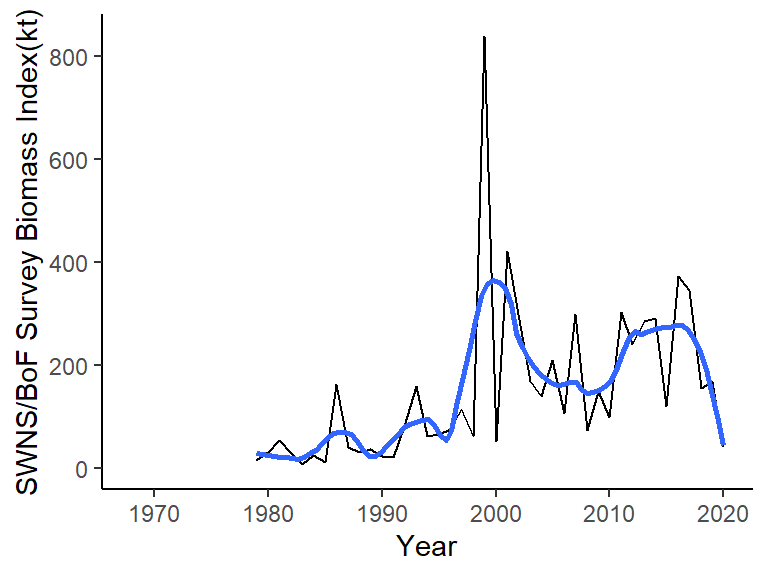

**Figure 2.2.6 Biomass Index from groundfish RV survey (Strata with sufficient data in SWNS/BoF)**  
*Blue line = loess smoother with span = 0.25*

[figure not shown]

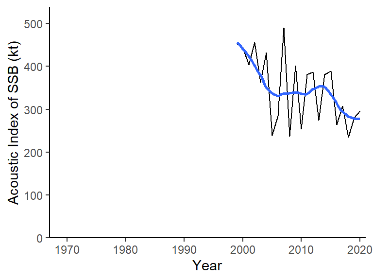

**Figure 2.2.8 Spawning Stock Biomass Index from acoustic survey on spawning grounds (SWNS/BoF: Scots Bay and German Bank**  
*Blue line = loess smoother with span = 0.5*

### Coastal

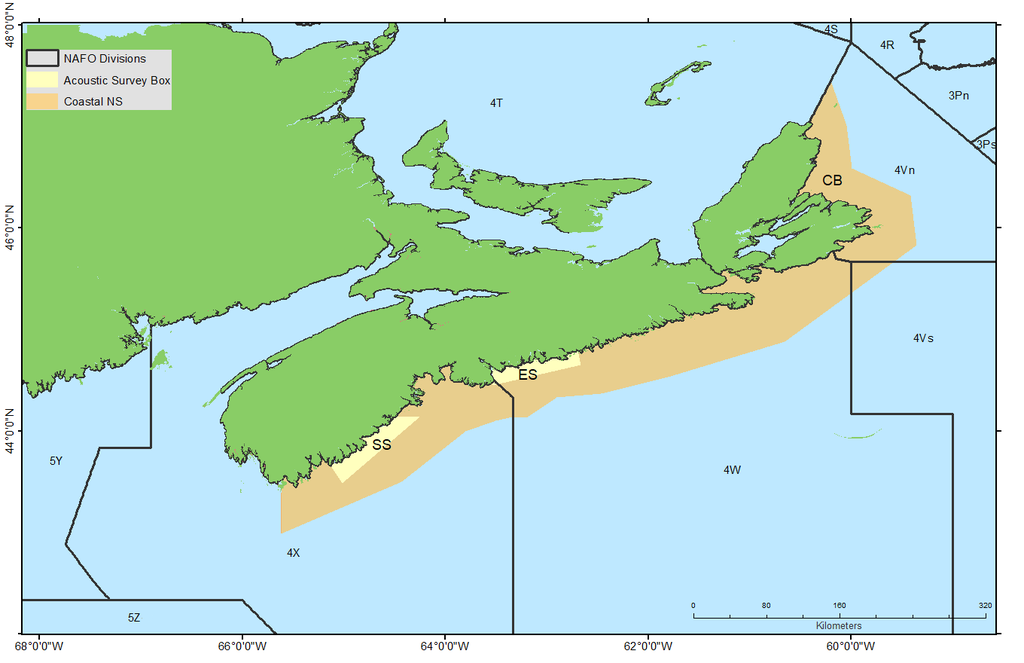

**Figure 2.3.1 Map of spatial area of the Coastal management component and survey boxes for South Shore (SS) and Eastern Shore (EA)**  
*Note: Only schools are surveyed within the survey boxes (not a complete survey of the area)*

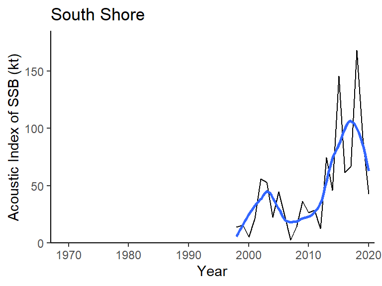

**Figure 2.3.2 Spawning Stock Biomass Index from acoustic survey on spawning grounds (South Shore)**  
*Blue line = loess smoother with span = 0.5*

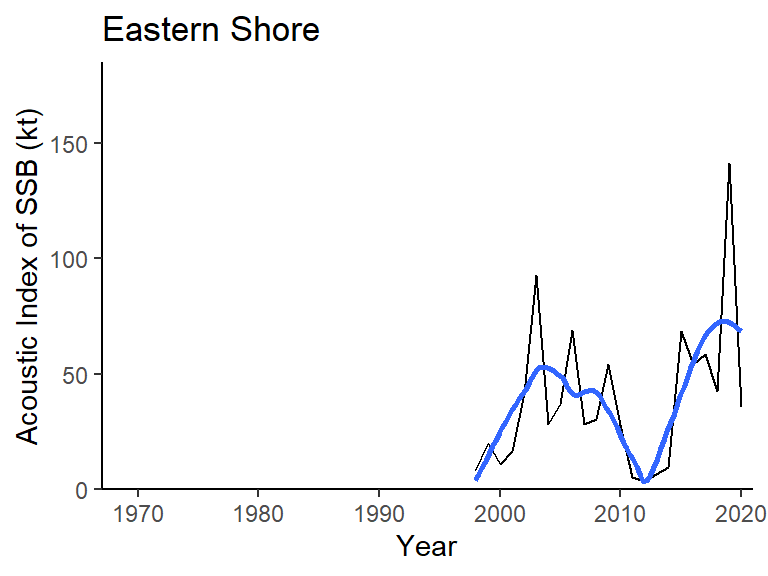

**Figure 2.3.3 Spawning Stock Biomass Index from acoustic survey on spawning grounds (Eastern Shore)**  
*Blue line = loess smoother with span = 0.5*